# Spatial forecasting of forest cover change in the humid tropics over the 21st century

Ghislain VIEILLEDENT, Christelle VANCUTSEM, and Frédéric ACHARD

22 janvier, 2021

# Abstract

**Keywords:** deforestation, forecasts, forest cover change, forest refuge areas, moist tropical forests, spatial modelling, scenarios.

**One sentence summary:** Tropical moist forests will still exist at the end of the 21$^{\text{st}}$ century, but not everywhere in the tropics.

# Introduction

Climate change and biodiversity loss pose unprecedented threats to human civilization (Cardinale *et al.* 2012; IPCC 2014; IPBES 2019). Tropical forests are at the heart of concerns when it comes to climate change and biodiversity loss. Commonly called the “Jewels of the Earth”, they shelter 30 million species of plants and animals representing half of the Earth’s wildlife and at least two-thirds of its plant species (Gibson *et al.* 2011; Wilson *et al.* 2012). Through carbon sequestration, they play an important role in the global carbon cycle, and in regulating the global climate (Bonan 2008; Pan *et al.* 2011; Baccini *et al.* 2017). Intact tropical forest ecosystems also prevent zoonoses outbreak and decrease the risk of pandemics (Dobson *et al.* 2020; Tollefson 2020; IPBES 2020). At the local scale, tropical forests regulate the regional climate (Dickinson & Kennedy 1992), cooling the atmosphere (Ellison *et al.* 2017; De Frenne *et al.* 2019), and facilitate access to water (Ellison *et al.* 2017). They also provide protection against erosion and flooding (Bradshaw *et al.* 2007). Close to 1.6 billion people (a quarter of the world’s population) rely on forest resources for their livelihoods (FAO 2015). Despite the many ecosystem services they provide, tropical forests are disappearing at an alarming rate (Hansen *et al.* 2013; Achard *et al.* 2014; Keenan *et al.* 2015; Vancutsem *et al.* 2020), mostly because of human activities (Geist & Lambin 2002; Curtis *et al.* 2018). Currently, around 8 Mha (twice the size of Switzerland) of tropical forest are disappearing each year (FAO 2015). At this rate, will there still be tropical forests in 2100, where will they be concentrated, and what will be the consequences of tropical deforestation on climate and biodiversity in the future?

Forecasting forest cover change is paramount as it allows to anticipate the consequences of deforestation (in terms of carbon emissions, biodiversity loss, or water supply) under various technological, political and socio-economic scenarios, and inform decision makers accordingly (Clark *et al.* 2001). The business-as-usual scenario is of particular interest as it allows to anticipate the likely future in the absence of change, and thus alert decision-makers, if necessary, to an essential change of course in order to avoid any potential environmental disaster. If scenarios of carbon dioxide emissions and climate change have been developed for several years by the Intergovernmental Panel on Climate Change (IPCC 2014), and are now largely used by the scientific community and known to the general public, there is currently no equivalent scenarios at the global scale for land-use change and biodiversity (IPBES 2019). Spatialized scenarios of forest cover change are particularly important because both forest carbon stocks (Avitabile *et al.* 2016; Baccini *et al.* 2017) and biodiversity (Allnutt *et al.* 2008; Kremen *et al.* 2008; Mittermeier *et al.* 2011) vary considerably in space at fine scale. Non-spatial scenarios of forest cover change (FAO 2015) cannot be used to accurately forecast associated carbon emissions and change in biodiversity, nor for systematic conservation planning at the local scale. Spatial forecasts of forest cover change rest on spatial statistical models which allow estimating a probability of change in space as a function of a set of spatial predictors. In addition to the forecasts, models can be used to identify the main drivers of deforestation and quantify their relative effects. For example, models can be used to assess the impact of roads on the risk of deforestation (Laurance *et al.* 2014) and the effectiveness of protected areas at reducing deforestation (Andam *et al.* 2008).

# Spatial modelling of deforestation

In the present study, we modelled the spatial deforestation process for 119 study-areas representing 92 countries in the three tropical continents (America, Africa, and Asia). Study-areas covered the integrality of the tropical moist forest in the world, at the exception of some islands (eg. Sao Tome and Principe or Wallis-and-Futuna). For each study-area, we derived historical forest cover change maps on two periods of time: 1$^{\text{st}}$ January 2000 – 1$^{\text{st}}$ January 2010, and 1$^{\text{st}}$ January 2010 – 1$^{\text{st}}$ January 2020, from the forest cover change annual product by Vancutsem *et al.* (2020) at 30 m resolution. An interactive forest cover change map for the humid tropics is available at https://forestatrisk.cirad.fr/tropics. For our forest definition, we only considered *natural old-growth tropical moist forests*, disregarding plantations and regrowths. We included degraded forests (not yet deforested) in our forest definition. To explain the observed deforestation on the period 2010–2020, we considered a set of spatial explanatory variables describing: topography (altitude and slope, 90 m resolution), accessibility (distances to nearest road, town, and river, 150 m resolution), forest landscape (distance to forest edge, 30 m resolution), deforestation history (distance to past deforestation, 30 m resolution), and land conservation status (presence of a protected area, 30 m resolution). This set of variables were selected on an *a priori* knowledge of the spatial deforestation process (Brown & Pearce 1994; Geist & Lambin 2002; Soares-Filho *et al.* 2006; Soares-Filho *et al.* 2010; Gorenflo *et al.* 2011; Vieilledent, Grinand & Vaudry 2013). Data for explanatory variables were extracted from extensive global data-sets (World Database on Protected Areas, SRTM Digital Elevation Database, and OpenStreetMap) and had a resolution close to the original resolution of the forest cover change map (30 m).

For each study-area, we built a large dataset from a sample of forest cover change observations in the period 2010–2020. We performed a stratified balanced sampling between deforested and non-deforested pixels in the period 2010–2020. Pixels in each category were sampled randomly. The number of sampled observations in each study-areas was a function of the forest cover area in 2010. Datasets included between 2,701 (for Sint Maarten island in America) and 100,000 (for study-areas with high forest cover such as the Amazonas state in Brazil, Peru, DRC, and Indonesia) observations. The global data-set included a total of 3,186,698 observations: 1,601,810 of non-deforested pixels and 1,584,888 of deforested pixels, corresponding to areas of 144,163 ha and 142,647 ha, respectively.

Using sampled observations of forest cover change in the period 2010–2020, we modelled the spatial probability of deforestation as a function of the explanatory variables using a logistic regression. To account for the residual spatial variation in the deforestation process, we included additional spatial random effects for the cells of a 10 $\times$ 10 km spatial grid covering each study-area. Spatial random effects account for unmeasured or unmeasurable variables (Clark 2005) that explain a part of the residual spatial variation in the deforestation process which is not explained by the fixed spatial explanatory variables already included in the model (such as local population density, local environmental law enforcement, etc.). Spatial random effects were assumed spatially autocorrelated through an intrinsic conditional autoregressive (iCAR) model (Besag, York & Mollié 1991; Banerjee, Carlin & Gelfand 2014). Variable selection for each study area was performed using a backward elimination procedure and parameter inference was done in a hierarchical Bayesian framework.

We compared the performance of the iCAR model at predicting the spatial probability of deforestation with three other statistical models: a null model, a simple generalized linear model (equivalent to a simple logistic regression without spatial random effects), and a Random Forest model. These two last models have been commonly used for deforestation modelling (Soares-Filho, Cerqueira & Pennachin 2002; Eastman & Toledano 2017; Santos 2019; Grinand *et al.* 2020). Using a cross-validation procedure, we showed that the Random Forest model was clearly overfitting the data and was less performant at predicting the probability of deforestation at new sites than the iCAR model. The iCAR model had a better predictive performance than the three other statistical models. Also, the iCAR model increased the explained deviance from 38.8 to 52.2% in average in comparison with the simple generalized linear model. This shows that environmental explanatory variables alone explain a relative small part of the spatial deforestation process, and that including spatial random effects to account for unexplained residual spatial variability strongly improves model’s fit (+13.4% of deviance explained in average) and model predictive performance (+6.9% for the TSS for example). Same results were obtained when comparing accuracy indices between models at the continental scale.

Using rasters of explanatory variables at their original resolution, and the fitted iCAR model for each study-area including estimated spatial random effects, we computed the spatial probability of deforestation at 30 m resolution for the year 2020 for each study-area (Fig. 2). An interactive global map of the spatial probability of deforestation is available at https://forestatrisk.cirad.fr/tropics. For each study-area, we also estimated the mean annual deforested area (in ha/yr) observed in the most recent period 2010–2020 from the forest cover change map for that period. Using the mean annual deforested area in combination with the spatial probability of deforestation map, we forecasted the forest cover change on the period 2020–2100 with a time step of 10 years, assuming a “business-as-usual” scenario. The business-as-usual scenario makes the assumption of an absence of change in both the deforestation intensity and the spatial deforestation probability in the future.

While similar studies have been performed at the scale of the Amazonian basin (Soares-Filho *et al.* 2006; Soares-Filho *et al.* 2010) using coarser data (1 km resolution), this is to our knowledge the first study which aims at modelling the spatial deforestation process at the pantropical scale using (i) high resolution data, (ii) extensive datasets of spatial explanatory variables, and (iii) site specific parameters. Modelling deforestation at a resolution closest to the resolution of the forest cover change map (30 m) ensures the capture of fine spatial scale deforestation processes. In particular, we demonstrated the preponderant effect of the distance to forest edge which acts at a distance much lower than 1 km on the risk of deforestation (Fig. 1). To perform our study, we used the new `forestatrisk` Python package which has been specifically developed to model and forecast deforestation at high resolution on large spatial scales through the use of efficient numerical computation libraries such as NumPy (Harris *et al.* 2020).

# Effectiveness of protected areas at displacing deforestation

To test the effect of protected areas on deforestation, we used an extensive dataset of protected areas in the tropics (Fig. S4) obtained from the World Database on Protected Areas (https://www.protectedplanet.net, UNEP-WCMC & IUCN (2020)). We considered protected areas of all IUCN categories (from Ia to VI) and of all types defined at the national level (e.g. National Parks, Reserves).

Forested protected areas are usually placed in areas of high or unique biodiversity, in a non-random way. Protected areas are usually found in remote places with lower human disturbances and reduced accessibility, i.e. far from roads or cities (Fig. S4), and usually at higher elevation, because low-lying arable lands have already been preempted for agriculture (Geist & Lambin 2002; López-Carr 2004). As a consequence, it is usually difficult to unravel the effect of protected areas from other correlated variables, for example distance to nearest road, city, or elevation (Andam *et al.* 2008). Our multivariate logistic regression model allows disentangling the effect of each explanatory variable included in the spatial deforestation model. Moreover, the spatial random effects included in our model are correcting for potential bias in the protected area effect that could be associated with other unmeasured confounding variables, such as population density (Andam *et al.* 2008).

We found that protected areas significantly reduced the risk of deforestation for 69 study-areas out of 119 (58% of the study-areas). These 69 study-areas accounted for 83% of the tropical moist forest in 2010 (Table S16). On average, protected areas reduce the risk of deforestation by 37% (Fig. 1 and Table S15). This is a clear result demonstrating the efficiency of protected areas at reducing the spatial risk of deforestation in the tropics. While other studies have assessed the effect of protected areas at reducing deforestation for particular countries or regions (Bruner 2001; Andam *et al.* 2008; Soares-Filho *et al.* 2010; Green *et al.* 2013) or at efficiently protecting particular group of species (Cazalis *et al.* 2020), our study is the first to assess the effect of protected areas on deforestation at the pantropical scale, using an extensive dataset on protected areas and potential confounding variables, an appropriate statistical model (Andam *et al.* 2008), and accurate pantropical forest-cover change maps (Vancutsem *et al.* 2020).

Our study, as other studies reporting the effect of protected areas on deforestation, demonstrates that protected areas are effective at *displacing* deforestation outside protected areas in tropical countries, but not necessarily that protected areas play a role at *reducing* the deforestation intensity per se. Indeed, factors driving the intensity of deforestation at the country scale are more socio-economic or political, such as the economic development level, which determines people livelihood and the link between people and deforestation (Brown & Pearce 1994; Geist & Lambin 2002; López-Carr 2004), the population size (Barnes 1990), or the environmental policy (Soares-Filho *et al.* 2014). In tropical countries with weak governance (where the environmental law enforcement is low) and with a low development level (where the pressure on forest is high), it is very unlikely that protected areas will remain forested. Under a business-as-usual scenario of deforestation, we assume that the deforestation intensity will remain constant through time. When all the forest outside the protected areas will be deforested, deforestation should occur inside protected areas (Fig. 3). In this scenario, protected areas are efficient at protecting forest areas of high and unique biodiversity in the mid term. In the mid term, forest will be concentrated in protected areas, where the deforestation probability is lower. In the long term, under a business as usual scenario, forest should completely disappear from protected areas as deforestation progresses (Fig. 3). This phenomenon is already clearly observable in countries or states where deforestation is advanced, such as in the Rondonia state (Brazil) in America (Ribeiro, Veríssimo & Pereira 2005), Ivory Coast (Sangne *et al.* 2015) or Madagascar (Vieilledent *et al.* 2020) in Africa, or Cambodia (Davis *et al.* 2015) in Asia. In these countries, several forested protected areas have been entirely (the Haut-Sassandra protected forest in Ivory-Coast, or the PK-32 Ranobe national park in Madagascar) or severely (e.g the Beng Per wildlife sanctuary in Cambodia) deforested.

Although protected areas, being efficient at displacing deforestation toward areas of lower biodiversity, can help us save some time in the fight against deforestation and biodiversity collapse, it is utterly urgent to find political and socio-economical solutions that are efficient at curbing the currently rampant deforestation on the long term. These solutions go in part through the fight against imported deforestation and an increase in international aid to tropical developing countries, which must be better targeted towards strong enforcement of environmental laws, education and sensibilisation of local communities to environmental stakes, the fight against corruption, the development of a more productive and environmentally friendly agriculture, and the fight against poverty (Geist & Lambin 2002; López-Carr, Suter & Barbieri 2005; Soares-Filho *et al.* 2014; Jones *et al.* 2019; Pendrill *et al.* 2019; Vieilledent *et al.* 2020).

# Impact of roads on deforestation

We also used an extensive dataset of roads in the tropics (Fig. S5) obtained from OpenStreetMap (OSM) (https://www.openstreetmap.org/) to estimate the effect of the distance to road on the risk of deforestation. Roads included “motorway”, “trunk”, “primary”, “secondary”, and “tertiary” roads from OSM. Distance to the nearest road was computed at 150 m resolution.

We found that a higher distance to the road significantly reduced the risk of deforestation for 58 study-areas out of 119 (49% of the study-areas). These 58 study-areas accounted for 90% of the tropical moist forest in 2010 (Table S16). On average, a distance of 10 km from a road reduces the risk of deforestation by 14% (Fig. 1 and Table S15). This said, where there is a road in a forest landscape, there is a forest edge. Indeed, opening a road in the forest implies the creation of two forest edges and computing a distance from a forest pixel to the nearest road implies the existence of a distance to forest edge. This means that when studying the effect of roads on deforestation, it is impossible not considering also the effect of the distance to forest edge on the deforestation risk.

Consequently, building new roads in non-forest areas but close to already existing forest edges would significantly increase the deforestation risk in the nearby forest. But this negative impact is substantially stronger if the development of roads is done at the heart of a forest area. In addition to the direct deforestation associated with road building in the forest (Kleinschroth & Healey 2017), this would imply the creation of new forest edges, and would dramatically increase the deforestation probability in this area. While road networks are expanding rapidly worldwide, notably in remote areas in tropical countries (Laurance *et al.* 2014), our results underline the importance of conserving large roadless and connected (unfragmented) forest areas.

# Remaining forests in 2100

At the country scale, 59 study areas (33 in America, 19 in Africa, and 7 in Asia) out of 119 will experience a complete loss of their tropical forests before 2100 (Table S10 and Fig. 3). When considering only study-areas with more than 1 Mha of forest in 2020, this represents 21 study-areas (9 in America, 7 in Africa, and 5 in Asia) out of 63. These 21 study-areas include most of the countries of Central America (Mexico, Guatemala, Honduras, Nicaragua), of Western (Sierra Leone, Ivory Coast, Ghana, Nigeria) and Eastern (Ethiopia, Madagascar) Africa, and of continental Asia (Myanmar, Laos, Vietnam, Cambodia, Indian Western Ghats). These countries represent almost all the tropical forest of 6 biodiversity hotspots identified by Mittermeier *et al.* (2011): Mesoamerica, Guinean Forests of West Africa, Horn of Africa, Madagascar and Indian Ocean Islands, Indo-Burma, Western Ghats and Sri Lanka.

Regarding the remaining tropical moist forest in 2100, three large blocks of relatively intact forest should emerge (Fig. 3 and interactive map of projected deforestation in 2020–2100 available at https://forestatrisk.cirad.fr/tropics). A first forest block will be located in America and will include the upper part of the Amazonian Basin (including the Peruvian, Ecuadorian, Colombian and Venezuelan Amazonia) and the Guyana Plateau (Guyana, Suriname, and French Guiana). A second one will be located in West Central Africa and will include forests from Gabon, Equatorial Guinea, Cameroon, Central African Republic, and Congo. A third one will be located in Melanesia and will include forests from Papua New Guinea, Solomon Islands and Vanuatu.

Apart from these three large and relatively intact forest blocks, the remaining tropical moist forest in 2100 will be highly fragmented (Fig. 3). In America, highly fragmented forest will be found in the Brazilian states of the Amazonian deforestation arc (Acre, Rondonia, Mato Grosso, Para, Amapa) and in the Roraima state in the North of Amazonia. In Africa, forests of the Democratic Republic of the Congo will also be highly fragmented and will be completely separated from the large forest block at the West of the Congo River. In Asia, small patches of heavily fragmented forests will remain in Malaysia, Indonesia and in the Philippines (Fig. 3). Remaining forests will be concentrated in remote areas (far from roads and villages), preferentially in protected areas, and at high elevation. For example, remaining forests in Borneo will be concentrated in the Betung Kerihun and Kayan Mentarang National Parks.

As tropical forests shelter most of the terrestrial biodiversity and stock most of the carbon on land, projected deforestation will likely have dramatical effects on future biodiversity loss and climate change. While the impact of projected deforestation on carbon emissions will be discussed below, completing a rigorous assessment of the impact of the projected deforestation on biodiversity is out of the scope of this study. Such analysis would require accurate species distribution and biodiversity maps including a high number of species representative of the biodiversity in the tropics (Allnutt *et al.* 2008). Such maps are not available to date (but see Jetz, McPherson & Guralnick (2012), Jenkins, Pimm & Joppa (2013), or Pimm *et al.* (2014)). Nonetheless, as a first estimate, if we only consider the endemic species (Mittermeier *et al.* 2011) from the 6 biodiversity hotspots where almost all the tropical forest is predicted to disappear by 2100, and assuming that most of these species depend on tropical moist forests, deforestation would induce the extinction of 29,140 species of plants and 4,576 species of vertebrates (including birds, reptiles, amphibians, freshwater fishes, and mammals) which cannot be found anywhere else on Earth.

# Carbon emissions under a business-as-usual scenario of deforestation

We estimated the carbon emissions associated with projected deforestation in the period 2020–2100 under a “business-as-usual” scenario of deforestation. We used a time step of 10 years to project the change in carbon emissions with time. To do so, we used the pantropical 1 km resolution aboveground dry biomass (AGB, in Mg/ha) map by Avitabile *et al.* (2016) (Fig. S12). Biomass can be converted into carbon emissions using the Intergovernmental Panel on Climate Change (IPCC) default carbon fraction of 0.47 (McGroddy, Daufresne & Hedin 2004). Although a large uncertainty surrounds the biomass estimates, Avitabile’s map is the most accurate biomass map available at the pantropical scale, and represents correctly the aboveground biomass spatial variability. We assumed no change of the forest carbon stocks in the future while computing carbon emissions associated with projected deforestation. Under a “business-as-usual” scenario of deforestation (no change in the annual deforested area, in ha/yr, in the future), the change in mean annual carbon emissions in the future is only attributable to the spatial variation of the forest carbon stocks and to the location of the future deforestation.

Increase in carbon emissions is explained by the fact that forest areas which are progressively deforested have higher carbon stocks. Several previous studies have shown that elevation is an important variable determining forest carbon stocks (Keith, Mackey & Lindenmayer 2009; Saatchi *et al.* 2011; Stegen *et al.* 2011; Baccini *et al.* 2012; Vieilledent *et al.* 2016). Forest carbon stocks are expected to be optimal at mid elevation (Asner *et al.* 2012; Vieilledent *et al.* 2016), because of higher orographic precipitation, and because the climatic stress associated with strong wind and low temperature is lower at mid elevation than at high elevation. In the present study, we show that low-elevation areas are preferentially deforested in comparison with high-elevation areas (Tables S12 and S13). This is explained by the fact that low-elevation areas are more accessible and because more arable lands are concentrated at low elevation, where the slope is usually lower and the soil is more productive (Geist & Lambin 2002; López-Carr 2004). Consequently, increase in carbon emissions in the future can be explained by the fact that deforestation progresses towards higher elevation areas where forest carbon stocks are higher. Moreover, remote forest areas that have been less disturbed by human activities in the past (Potapov *et al.* 2017) can have accumulated large quantities of carbon (Dargie *et al.* 2017; Brinck *et al.* 2017). The progressive deforestation of more intact forests can also explain the projected increase in carbon emissions in the future.

These results demonstrate the importance of having spatial predictions of deforestation to forecast the carbon emissions associated with deforestation. Under a business-as-usual scenario of deforestation, carbon emissions are the result of both the spatial variation of the forest carbon stocks and the location of the future deforestation. The projected increase in carbon emission estimates with time would have been hard to anticipate with mean annual forest cover change estimates by country and forest type (such as those provided by the Forest Resource Assessment report for example, Keenan *et al.* (2015)) and mean forest carbon stocks by continent and forest type (such as the emission factors provided by IPCC (2019)).

# Alternative deforestation scenarios and research perspectives

# Acknowledgements

Authors warmly thank Rémy Dernat and Philippe Verley for their help on using the computing cluster of the Montpellier Bioinformatics Biodiversity (MBB) platform. **Funding**: BioSceneMada project funded by FRB-FFEM (AAP-SCEN-2013 I), Roadless Forest funded by the European Commission, RELIQUES project funded by CNRT, LabEx CeMEB funded by ANR “Investissements d’avenir” program (ANR-10-LABX-04-01). **Authors contributions**: GV and FA conceived the study, CV provided the historical forest cover change maps and advice on using the deforestation annual product, GV performed the analysis and wrote the original draft, all authors reviewed and edited the final manuscript. **Competing interests**: All authors declare that they have no competing interests. **Data and materials availability**: All data, code, and materials used for the analysis are available in the following GitHub repository: https://github.com/ghislainv/forestatrisk-tropics.

# Supplementary Materials

Materials and Methods  
Figs. S1 to S13  
Tables S1 to S18  
Data S1 to S2  
References

# Tables

Table 1: **Historical and projected forest cover change**. We provide historical and projected forest cover areas for the three continents and the three countries having the highest forest cover in 2010 in each continent (Brazil in America, DRC in Africa, and Indonesia in Asia). Historical forest cover areas (in thousand hectares, Kha) are provided for the years 2000, 2010 and 2020 (“fc2000”, “fc2010”, and “fc2020”, respectively), together with the mean annual deforested area $d$ (Kha/yr) for the period 2010–2020. We computed the corresponding mean annual deforestation rate $p$ (%/yr) for the period 2010–2020. Projected forest cover areas are given for the years 2050 and 2100 (“fc2050” and “fc2100”). Projections were made using the forest cover in 2020 and the mean annual deforested area in the period 2010–2020 (“fc2020” and $d$, respectively), assuming a “business-as-usual” scenario of deforestation. Column “loss21” indicates the projected percentage of forest cover loss during the 21$^\text{st}$ century (2100 vs. 2000). We computed the estimated year at which 75% of the forest cover in 2000 will have disappeared (“yr75”).

| Regions | fc2000 (Kha) | fc2010 (Kha) | fc2020 (Kha) | $d$ (Kha/yr) | $p$ (%/yr) | fc2050 (Kha) | fc2100 (Kha) | loss21 (%) | yr75 |
| --- | --- | --- | --- | --- | --- | --- | --- | --- | --- |
| **Countries** |  |  |  |  |  |  |  |  |  |
| Brazil | 375,892 | 349,784 | 334,982 | 1,537 | 0.4 | 277,094 | 180,614 | 52 | 2146 |
| DRC | 131,617 | 126,164 | 117,812 | 860 | 0.7 | 88,077 | 38,520 | 71 | 2099 |
| Indonesia | 141,244 | 127,699 | 116,317 | 1,215 | 1.0 | 71,357 | 0 | 100 | 2070 |
| **Continents** |  |  |  |  |  |  |  |  |  |
| America | 690,337 | 648,916 | 621,160 | 2,892 | 0.5 | 513,688 | 356,248 | 41 | 2197 |
| Africa | 275,709 | 259,665 | 238,791 | 2,176 | 0.9 | 171,760 | 100,559 | 58 | 2143 |
| Asia | 301,391 | 270,679 | 246,894 | 2,533 | 1.0 | 153,946 | 38,431 | 78 | 2094 |
| All cont. | 1,267,437 | 1,179,260 | 1,106,845 | 7,601 | 0.7 | 839,394 | 495,237 | 61 | 2142 |

# Figures

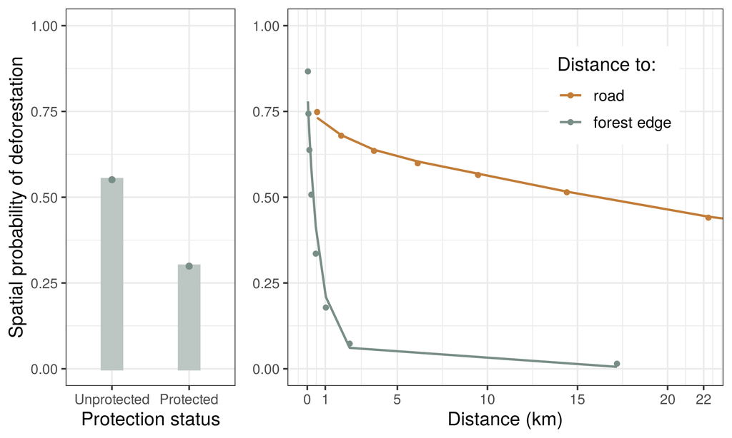

Figure 1: **Effects of explanatory variables on the spatial probability of deforestation**. For this figure, we used a representative data-set at the global scale where the number of observations for each study-area was proportional to its forest cover in 2010. The total number of observations changed from 3,186,698 to 813,796. *Left*: Points represent the observed mean probability of deforestation in each class of forest’s protection status, either protected or unprotected. Bars represent the mean of the predicted probabilities of deforestation obtained from the iCAR model of deforestation for all observations in each class. *Right*: Points represent the local mean probability of deforestation for each bins of 10 percentiles for the distances (first point for distance to forest edge includes 3 bins, some bins corresponding to a distance > 22 km for distance to road are not shown). Lines represent the mean of the predicted probabilities of deforestation obtained from the iCAR model of deforestation for all observations in each bin.

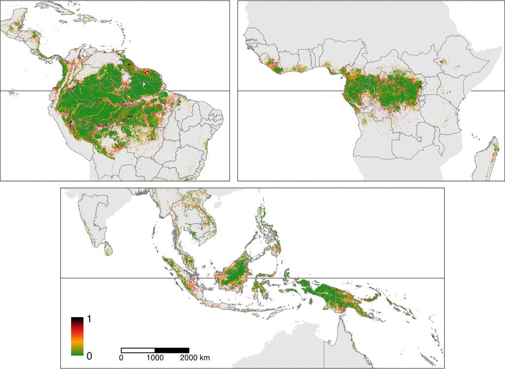

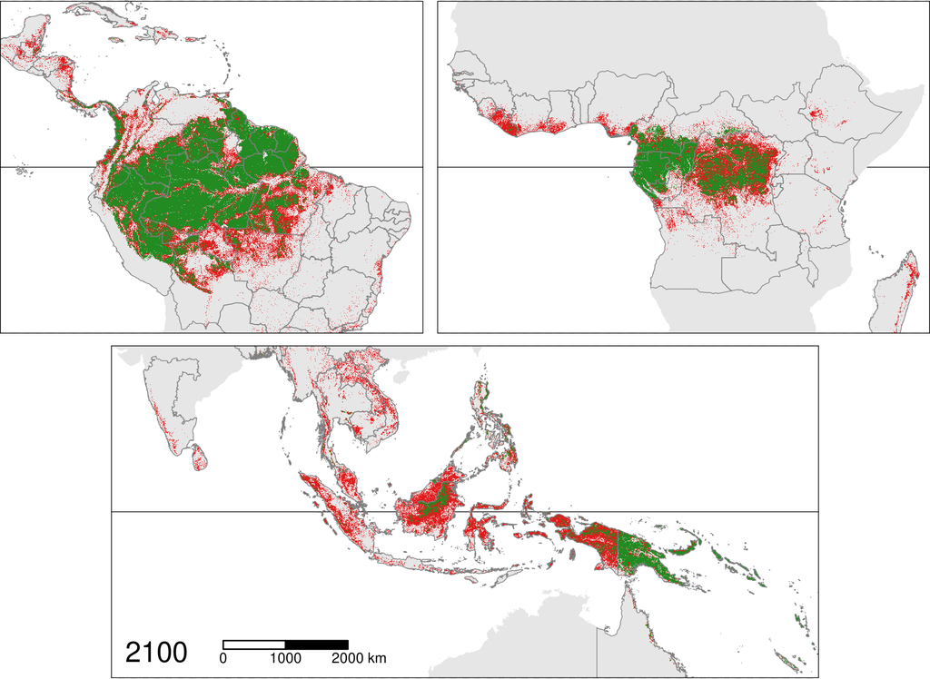

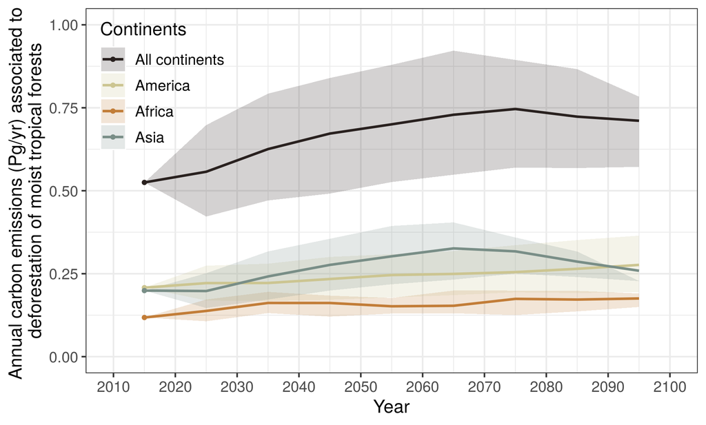

# References

Achard, F., Beuchle, R., Mayaux, P., Stibig, H.-J., Bodart, C., Brink, A., Carboni, S., Desclée, B., Donnay, F., Eva, H.D., Lupi, A., Raši, R., Seliger, R. & Simonetti, D. (2014) Determination of tropical deforestation rates and related carbon losses from 1990 to 2010. *Global Change Biology*, **20**, 2540–2554.

Allnutt, T.F., Ferrier, S., Manion, G., Powell, G.V.N., Ricketts, T.H., Fisher, B.L., Harper, G.J., Irwin, M.E., Kremen, C., Labat, J.-N., Lees, D.C., Pearce, T.A. & Rakotondrainibe, F. (2008) A method for quantifying biodiversity loss and its application to a 50-year record of deforestation across madagascar. *Conservation Letters*, **1**, 173–181.

Andam, K.S., Ferraro, P.J., Pfaff, A., Sanchez-Azofeifa, G.A. & Robalino, J.A. (2008) Measuring the effectiveness of protected area networks in reducing deforestation. *Proceedings of the National Academy of Sciences*, **105**, 16089–16094.

Asner, G., Clark, J.K., Mascaro, J., Vaudry, R., Chadwick, K.D., Vieilledent, G., Rasamoelina, M., Balaji, A., Kennedy-Bowdoin, T., Maatoug, L., Colgan, M.S. & Knapp, D.E. (2012) Human and environmental controls over aboveground carbon storage in madagascar. *Carbon Balance and Management*, **7**, 2–.

Avitabile, V., Herold, M., Heuvelink, G.B.M., Lewis, S.L., Phillips, O.L., Asner, G.P., Armston, J., Ashton, P.S., Banin, L., Bayol, N., Berry, N.J., Boeckx, P., Jong, B.H.J. de, DeVries, B., Girardin, C.A.J., Kearsley, E., Lindsell, J.A., Lopez-Gonzalez, G., Lucas, R., Malhi, Y., Morel, A., Mitchard, E.T.A., Nagy, L., Qie, L., Quinones, M.J., Ryan, C.M., Ferry, S.J.W., Sunderland, T., Laurin, G.V., Gatti, R.C., Valentini, R., Verbeeck, H., Wijaya, A. & Willcock, S. (2016) An integrated pan-tropical biomass map using multiple reference datasets. *Global Change Biology*, **22**, 1406–1420.

Baccini, A., Goetz, S.J., Walker, W.S., Laporte, N.T., Sun, M., Sulla-Menashe, D., Hackler, J., Beck, P.S.A., Dubayah, R., Friedl, M.A., Samanta, S. & Houghton, R.A. (2012) Estimated carbon dioxide emissions from tropical deforestation improved by carbon-density maps. *Nature Climate Change*, **2**, 182–185.

Baccini, A., Walker, W., Carvalho, L., Farina, M., Sulla-Menashe, D. & Houghton, R.A. (2017) Tropical forests are a net carbon source based on aboveground measurements of gain and loss. *Science*, **358**, 230–234.

Banerjee, S., Carlin, B.P. & Gelfand, A.E. (2014) *Hierarchical Modeling and Analysis for Spatial Data, Second Edition*. Chapman; Hall/CRC.

Barnes, R.F.W. (1990) Deforestation trends in tropical africa. *African Journal of Ecology*, **28**, 161–173.

Besag, J., York, J. & Mollié, A. (1991) Bayesian image restoration, with two applications in spatial statistics. *Annals of the Institute of Statistical Mathematics*, **43**, 1–20.

Bonan, G.B. (2008) Forests and climate change: Forcings, feedbacks, and the climate benefits of forests. *Science*, **320**, 1444–1449.

Bradshaw, C.J.A., Sodhi, N.S., Peh, K.S.-.H. & Brook, B.W. (2007) Global evidence that deforestation amplifies flood risk and severity in the developing world. *Global Change Biology*, **13**, 2379–2395.

Brinck, K., Fischer, R., Groeneveld, J., Lehmann, S., Dantas De Paula, M., Pütz, S., Sexton, J.O., Song, D. & Huth, A. (2017) High resolution analysis of tropical forest fragmentation and its impact on the global carbon cycle. *Nature Communications*, **8**, 14855.

Brown, K. & Pearce, D.W. (1994) *The Causes of Tropical Deforestation: The Economic and Statistical Analysis of Factors Giving Rise to the Loss of the Tropical Forests*. UBC press, Vancouver.

Bruner, A.G. (2001) Effectiveness of parks in protecting tropical biodiversity. *Science*, **291**, 125–128.

Cardinale, B.J., Duffy, J.E., Gonzalez, A., Hooper, D.U., Perrings, C., Venail, P., Narwani, A., Mace, G.M., Tilman, D., Wardle, D.A. & others. (2012) Biodiversity loss and its impact on humanity. *Nature*, **486**, 59–67.

Cazalis, V., Princé, K., Mihoub, J.-B., Kelly, J., Butchart, S.H.M. & Rodrigues, A.S.L. (2020) Effectiveness of protected areas in conserving tropical forest birds. *Nature Communications*, **11**.

Clark, J.S. (2005) Why environmental scientists are becoming bayesians. *Ecology Letters*, **8**, 2–14.

Clark, J.S., Carpenter, S.R., Barber, M., Collins, S., Dobson, A., Foley, J.A., Lodge, D.M., Pascual, M., Pielke, R., Pizer, W., Pringle, C., Reid, W.V., Rose, K.A., Sala, O., Schlesinger, W.H., Wall, D.H. & Wear, D. (2001) Ecological forecasts: An emerging imperative. *Science*, **293**, 657–660.

Curtis, P.G., Slay, C.M., Harris, N.L., Tyukavina, A. & Hansen, M.C. (2018) Classifying drivers of global forest loss. *Science*, **361**, 1108–1111.

Dargie, G.C., Lewis, S.L., Lawson, I.T., Mitchard, E.T.A., Page, S.E., Bocko, Y.E. & Ifo, S.A. (2017) Age, extent and carbon storage of the central congo basin peatland complex. *Nature*, **542**, 86–90.

Davis, K.F., Yu, K., Rulli, M.C., Pichdara, L. & D’Odorico, P. (2015) Accelerated deforestation driven by large-scale land acquisitions in cambodia. *Nature Geoscience*, **8**, 772–775.

De Frenne, P., Zellweger, F., Rodrı́guez-Sánchez, F., Scheffers, B.R., Hylander, K., Luoto, M., Vellend, M., Verheyen, K. & Lenoir, J. (2019) Global buffering of temperatures under forest canopies. *Nature Ecology & Evolution*, **3**, 744–749.

Dickinson, R.E. & Kennedy, P. (1992) Impacts on regional climate of amazon deforestation. *Geophysical Research Letters*, **19**, 1947–1950.

Dobson, A.P., Pimm, S.L., Hannah, L., Kaufman, L., Ahumada, J.A., Ando, A.W., Bernstein, A., Busch, J., Daszak, P., Engelmann, J., Kinnaird, M.F., Li, B.V., Loch-Temzelides, T., Lovejoy, T., Nowak, K., Roehrdanz, P.R. & Vale, M.M. (2020) Ecology and economics for pandemic prevention. *Science*, **369**, 379–381.

Eastman, J.R. & Toledano, J. (2017) A short presentation of the land change modeler (LCM). *Geomatic approaches for modeling land change scenarios*, pp. 499–505. Springer International Publishing.

Ellison, D., Morris, C.E., Locatelli, B., Sheil, D., Cohen, J., Murdiyarso, D., Gutierrez, V., Noordwijk, M. van, Creed, I.F., Pokorny, J., Gaveau, D., Spracklen, D.V., Tobella, A.B., Ilstedt, U., Teuling, A.J., Gebrehiwot, S.G., Sands, D.C., Muys, B., Verbist, B., Springgay, E., Sugandi, Y. & Sullivan, C.A. (2017) Trees, forests and water: Cool insights for a hot world. *Global Environmental Change*, **43**, 51–61.

Esquivel-Muelbert, A., Baker, T.R., Dexter, K.G., Lewis, S.L., Brienen, R.J.W., Feldpausch, T.R., Lloyd, J., Monteagudo-Mendoza, A., Arroyo, L., Álvarez-Dávila, E., Higuchi, N., Marimon, B.S., Marimon-Junior, B.H., Silveira, M., Vilanova, E., Gloor, E., Malhi, Y., Chave, J., Barlow, J., Bonal, D., Cardozo, N.D., Erwin, T., Fauset, S., Hérault, B., Laurance, S., Poorter, L., Qie, L., Stahl, C., Sullivan, M.J.P., Steege, H. ter, Vos, V.A., Zuidema, P.A., Almeida, E., Oliveira, E.A. de, Andrade, A., Vieira, S.A., Aragão, L., Araujo-Murakami, A., Arets, E., C, G.A.A., Baraloto, C., Camargo, P.B., Barroso, J.G., Bongers, F., Boot, R., Camargo, J.L., Castro, W., Moscoso, V.C., Comiskey, J., Valverde, F.C., Costa, A.C.L. da, Aguila Pasquel, J. del, Fiore, A.D., Duque, L.F., Elias, F., Engel, J., Llampazo, G.F., Galbraith, D., Fernández, R.H., Coronado, E.H., Hubau, W., Jimenez-Rojas, E., Lima, A.J.N., Umetsu, R.K., Laurance, W., Lopez-Gonzalez, G., Lovejoy, T., Cruz, O.A.M., Morandi, P.S., Neill, D., Vargas, P.N., Camacho, N.C.P., Gutierrez, A.P., Pardo, G., Peacock, J., Peña-Claros, M., Peñuela-Mora, M.C., Petronelli, P., Pickavance, G.C., Pitman, N., Prieto, A., Quesada, C., Ramı́rez-Angulo, H., Réjou-Méchain, M., Correa, Z.R., Roopsind, A., Rudas, A., Salomão, R., Silva, N., Espejo, J.S., Singh, J., Stropp, J., Terborgh, J., Thomas, R., Toledo, M., Torres-Lezama, A., Gamarra, L.V., Meer, P.J. van de, Heijden, G. van der, Hout, P. van der, Martinez, R.V., Vela, C., Vieira, I.C.G. & Phillips, O.L. (2018) Compositional response of amazon forests to climate change. *Global Change Biology*, **25**, 39–56.

FAO. (2015) *Global Forest Resources Assessment 2015*. Food; Agriculture Organization of the United Nations.

Geist, H.J. & Lambin, E.F. (2002) Proximate causes and underlying driving forces of tropical deforestation. *BioScience*, **52**, 143.

Gibson, L., Lee, T.M., Koh, L.P., Brook, B.W., Gardner, T.A., Barlow, J., Peres, C.A., Bradshaw, C.J.A., Laurance, W.F., Lovejoy, T.E. & Sodhi, N.S. (2011) Primary forests are irreplaceable for sustaining tropical biodiversity. *Nature*, **478**, 378–381.

Gorenflo, L.J., Corson, C., Chomitz, K.M., Harper, G., Honzák, M. & Özler, B. (2011) *Exploring the Association Between People and Deforestation in Madagascar* (eds R.P. Cincotta & L.J. Gorenflo). Springer Berlin Heidelberg.

Green, J.M.H., Larrosa, C., Burgess, N.D., Balmford, A., Johnston, A., Mbilinyi, B.P., Platts, P.J. & Coad, L. (2013) Deforestation in an african biodiversity hotspot: Extent, variation and the effectiveness of protected areas. *Biological Conservation*, **164**, 62–72.

Grinand, C., Vieilledent, G., Razafimbelo, T., Rakotoarijaona, J.-R., Nourtier, M. & Bernoux, M. (2020) Landscape-scale spatial modelling of deforestation, land degradation, and regeneration using machine learning tools. *Land Degradation & Development*, **31**, 1699–1712.

Hansen, M.C., Potapov, P.V., Moore, R., Hancher, M., Turubanova, S.A., Tyukavina, A., Thau, D., Stehman, S.V., Goetz, S.J., Loveland, T.R., Kommareddy, A., Egorov, A., Chini, L., Justice, C.O. & Townshend, J.R.G. (2013) High-resolution global maps of 21st-century forest cover change. *Science*, **342**, 850–853.

Hansen, M.C., Wang, L., Song, X.-P., Tyukavina, A., Turubanova, S., Potapov, P.V. & Stehman, S.V. (2020) The fate of tropical forest fragments. *Science Advances*, **6**, eaax8574.

Harris, N.L., Brown, S., Hagen, S.C., Saatchi, S.S., Petrova, S., Salas, W., Hansen, M.C., Potapov, P.V. & Lotsch, A. (2012) Baseline map of carbon emissions from deforestation in tropical regions. *Science*, **336**, 1573–1576.

Harris, C.R., Millman, K.J., Walt, S.J. van der, Gommers, R., Virtanen, P., Cournapeau, D., Wieser, E., Taylor, J., Berg, S., Smith, N.J., Kern, R., Picus, M., Hoyer, S., Kerkwijk, M.H. van, Brett, M., Haldane, A., Río, J.F. del, Wiebe, M., Peterson, P., Gérard-Marchant, P., Sheppard, K., Reddy, T., Weckesser, W., Abbasi, H., Gohlke, C. & Oliphant, T.E. (2020) Array programming with NumPy. *Nature*, **585**, 357–362.

IPBES. (2019) Summary for policymakers of the global assessment report on biodiversity and ecosystem services. The Intergovernmental Platform on Biodiversity and Ecosystem Services, IPBES, Bonn, Germany.

IPBES. (2020) Workshop Report on Biodiversity and Pandemics. The Intergovernmental Platform on Biodiversity and Ecosystem Services, IPBES, Bonn, Germany.

IPCC. (2014) *Climate Change 2014: Synthesis Report. Contribution of Working Groups I, II and III to the Fifth Assessment Report of the Intergovernmental Panel on Climate Change* (eds R.K. Pachauri & L.A. Meyer). The Intergovernmental Panel on Climate Change, IPCC, Geneva, Switzerland.

IPCC. (2019) *Refinement to the 2006 IPCC Guidelines for National Greenhouse Gas Inventories. Volume 4. Agriculture, Forestry and Other Land Use*. The Intergovernmental Panel on Climate Change, IPCC/IGES; IGES, Japan.

Jenkins, C.N., Pimm, S.L. & Joppa, L.N. (2013) Global patterns of terrestrial vertebrate diversity and conservation. *Proceedings of the National Academy of Sciences*, **110**, E2602–E2610.

Jetz, W., McPherson, J.M. & Guralnick, R.P. (2012) Integrating biodiversity distribution knowledge: Toward a global map of life. *Trends in Ecology & Evolution*, **27**, 151–159.

Jones, J.P.G., Ratsimbazafy, J., Ratsifandrihamanana, A.N., Watson, J.E.M., Andrianandrasana, H.T., Cabeza, M., Cinner, J.E., Goodman, S.M., Hawkins, F., Mittermeier, R.A., Rabearisoa, A.L., Rakotonarivo, O.S., Razafimanahaka, J.H., Razafimpahanana, A.R., Wilmé, L. & Wright, P.C. (2019) Last chance for madagascar’s biodiversity. *Nature Sustainability*, **2**, 350–352.

Karstensen, J., Peters, G.P. & Andrew, R.M. (2013) Attribution of C02 emissions from brazilian deforestation to consumers between 1990 and 2010. *Environmental Research Letters*, **8**, 024005.

Keenan, R.J., Reams, G.A., Achard, F., Freitas, J.V. de, Grainger, A. & Lindquist, E. (2015) Dynamics of global forest area: Results from the {FAO} global forest resources assessment 2015. *Forest Ecology and Management*, **352**, 9–20.

Keith, H., Mackey, B.G. & Lindenmayer, D.B. (2009) Re-evaluation of forest biomass carbon stocks and lessons from the world’s most carbon-dense forests. *Proceedings of the National Academy of Sciences*, **106**, 11635–11640.

Kleinschroth, F. & Healey, J.R. (2017) Impacts of logging roads on tropical forests. *Biotropica*, **49**, 620–635.

Kremen, C., Cameron, A., Moilanen, A., Phillips, S.J., Thomas, C.D., Beentje, H., Dransfield, J., Fisher, B.L., Glaw, F., Good, T.C., Harper, G.J., Hijmans, R.J., Lees, D.C., Louis, E., Nussbaum, R.A., Raxworthy, C.J., Razafimpahanana, A., Schatz, G.E., Vences, M., Vieites, D.R., Wright, P.C. & Zjhra, M.L. (2008) Aligning conservation priorities across taxa in madagascar with high-resolution planning tools. *Science*, **320**, 222–226.

Laurance, W.F., Clements, G.R., Sloan, S., O’Connell, C.S., Mueller, N.D., Goosem, M., Venter, O., Edwards, D.P., Phalan, B., Balmford, A., Ree, R.V.D. & Arrea, I.B. (2014) A global strategy for road building. *Nature*, **513**, 229–232.

López-Carr, D. (2004) Proximate population factors and deforestation in tropical agricultural frontiers. *Population and Environment*, **25**, 585–612.

López-Carr, D., Suter, L. & Barbieri, A. (2005) Population dynamics and tropical deforestation: State of the debate and conceptual challenges. *Population and Environment*, **27**, 89–113.

McGroddy, M.E., Daufresne, T. & Hedin, L.O. (2004) Scaling of C:N:P stoichiometry in forests worldwide: implications of terrestrial redfield-type ratios. *Ecology*, **85**, 2390–2401.

Mittermeier, R.A., Turner, W.R., Larsen, F.W., Brooks, T.M. & Gascon, C. (2011) Global biodiversity conservation: The critical role of hotspots. *Biodiversity hotspots*, pp. 3–22. Springer Berlin Heidelberg.

Pan, Y., Birdsey, R.A., Fang, J., Houghton, R., Kauppi, P.E., Kurz, W.A., Phillips, O.L., Shvidenko, A., Lewis, S.L., Canadell, J.G., Ciais, P., Jackson, R.B., Pacala, S.W., McGuire, A.D., Piao, S., Rautiainen, A., Sitch, S. & Hayes, D. (2011) A large and persistent carbon sink in the world’s forests. *Science*, **333**, 988–993.

Pendrill, F., Persson, U.M., Godar, J., Kastner, T., Moran, D., Schmidt, S. & Wood, R. (2019) Agricultural and forestry trade drives large share of tropical deforestation emissions. *Global Environmental Change*, **56**, 1–10.

Pimm, S.L., Jenkins, C.N., Abell, R., Brooks, T.M., Gittleman, J.L., Joppa, L.N., Raven, P.H., Roberts, C.M. & Sexton, J.O. (2014) The biodiversity of species and their rates of extinction, distribution, and protection. *Science*, **344**, 1246752–1246752.

Potapov, P., Hansen, M.C., Laestadius, L., Turubanova, S., Yaroshenko, A., Thies, C., Smith, W., Zhuravleva, I., Komarova, A., Minnemeyer, S. & Esipova, E. (2017) The last frontiers of wilderness: Tracking loss of intact forest landscapes from 2000 to 2013. *Science Advances*, **3**, e1600821.

Raftery, A.E., Li, N., Sevcikova, H., Gerland, P. & Heilig, G.K. (2012) Bayesian probabilistic population projections for all countries. *Proceedings of the National Academy of Sciences*, **109**, 13915–13921.

Ribeiro, B., Veríssimo, A. & Pereira, Kátia. (2005) O avanço do desmatamento sobre as áreas protegidas em rondônia. *O Estado da Amazônia (IMAZON)*, **5**, 1–5.

Saatchi, S.S., Harris, N.L., Brown, S., Lefsky, M., Mitchard, E.T.A., Salas, W., Zutta, B.R., Buermann, W., Lewis, S.L., Hagen, S., Petrova, S., White, L., Silman, M. & Morel, A. (2011) Benchmark map of forest carbon stocks in tropical regions across three continents. *Proceedings of the National Academy of Sciences*, **108**, 9899–9904.

Sangne, C.Y., Barima, Y.S.S., Bamba, I. & N’Doumé, C.-T.A. (2015) Dynamique forestière post-conflits armés de la forêt classée du haut-sassandra (côte d’ivoire). *VertigO*.

Santos, V.A.B., Fabián AND Graw. (2019) A geographically weighted random forest approach for evaluate forest change drivers in the northern ecuadorian amazon. *PLOS ONE*, **14**, 1–37.

Soares-Filho, B.S., Cerqueira, G.C. & Pennachin, C.L. (2002) DINAMICA - a stochastic cellular automata model designed to simulate the landscape dynamics in an amazonian colonization frontier. *Ecological Modelling*, **154**, 217–235.

Soares-Filho, B., Moutinho, P., Nepstad, D., Anderson, A., Rodrigues, H., Garcia, R., Dietzsch, L., Merry, F., Bowman, M., Hissa, L., Silvestrini, R. & Maretti, C. (2010) Role of brazilian amazon protected areas in climate change mitigation. *Proceedings of the National Academy of Sciences*, **107**, 10821–10826.

Soares-Filho, B.S., Nepstad, D.C., Curran, L.M., Cerqueira, G.C., Garcia, R.A., Ramos, C.A., Voll, E., McDonald, A., Lefebvre, P. & Schlesinger, P. (2006) Modelling conservation in the amazon basin. *Nature*, **440**, 520–523.

Soares-Filho, B., Rajao, R., Macedo, M., Carneiro, A., Costa, W., Coe, M., Rodrigues, H. & Alencar, A. (2014) Cracking brazils forest code. *Science*, **344**, 363–364.

Stegen, J.C., Swenson, N.G., Enquist, B.J., White, E.P., Phillips, O.L., Jørgensen, P.M., Weiser, M.D., Monteagudo Mendoza, A. & Núñez Vargas, P. (2011) Variation in above-ground forest biomass across broad climatic gradients. *Global Ecology and Biogeography*, **20**, 744–754.

Strona, G., Stringer, S.D., Vieilledent, G., Szantoi, Z., Garcia-Ulloa, J. & A. Wich, S. (2018) Small room for compromise between oil palm cultivation and primate conservation in africa. *Proceedings of the National Academy of Sciences*.

Tollefson, J. (2020) Why deforestation and extinctions make pandemics more likely. *Nature*, **584**, 175–176.

UNEP-WCMC & IUCN. (2020) Protected Planet: The World Database on Protected Areas (WDPA). On-line; 01-03/2020, Cambridge, UK: UNEP-WCMC and IUCN. Available at: www.protectedplanet.net., https://www.protectedplanet.net

Vancutsem, C., Achard, F., Pekel, J.-F., Vieilledent, G., Carboni, S., Simonetti, D., Gallego, J., Aragao, L. & Nasi, R. (2020) Long-term (1990-2019) monitoring of tropical moist forests dynamics. *bioRxiv*.

Vieilledent, G., Gardi, O., Grinand, C., Burren, C., Andriamanjato, M., Camara, C., Gardner, C.J., Glass, L., Rasolohery, A., Rakoto Ratsimba, H., Gond, V. & Rakotoarijaona, J.-R. (2016) Bioclimatic envelope models predict a decrease in tropical forest carbon stocks with climate change in Madagascar. *Journal of Ecology*, **104**, 703–715.

Vieilledent, G., Grinand, C. & Vaudry, R. (2013) Forecasting deforestation and carbon emissions in tropical developing countries facing demographic expansion: A case study in madagascar. *Ecology and Evolution*, **3**, 1702–1716.

Vieilledent, G., Nourtier, M., Grinand, C., Pedrono, M., Clausen, A., Rabetrano, T., Rakotoarijaona, J.-R., Rakotoarivelo, B., Rakotomalala, F.A., Rakotomalala, L., Razafimpahanana, A., Ralison, J.M. & Achard, F. (2020) It’s not just poverty: Unregulated global market and bad governance explain unceasing deforestation in western madagascar.

Wilson, J.B., Peet, R.K., Dengler, J. & Pärtel, M. (2012) Plant species richness: The world records. *Journal of Vegetation Science*, **23**, 796–802.